# 3.2 Correlation

## Goals

1. Interpret a correlation coefficient.
   - Describe the strength of a linear relationship.
   - Relate correlation coefficients to scatter plots.

## Correlation

Goal: formalize the concept of the *strength* of a linear relationship.

The **correlation** (or **correlation coefficient**) \(R\) between two variables describes the strength of their linear relationship.

\[R = \frac{1}{n-1}\sum_{i=1}^n\left(\frac{x_i - \bar{x}}{s_x}\times\frac{y_i - \bar{y}}{s_y}\right)\]

- \(s_x\) and \(s_y\) are the respective standard deviations for \(x\) and \(y\)
- The sample size \(n\) is the total number of \((x,y)\) pairs.
- \(R\) always takes values between \(-1\) and \(1\).

This is a pretty involved formula! We’ll let a computer handle this one.

Correlations

- close to \(-1\) suggest strong, negative linear relationships.
- close to \(+1\) suggest strong, positive linear relationships.
- close to \(0\) have little-to-no linear relationship.

Note: the sign of the correlation will match the sign of the slope!

- If \(R < 0\), there is a downward trend and \(b_1 < 0\).
- If \(R > 0\), there is an upward trend and \(b_1 > 0\).
- If \(R \approx 0\), there is no relationship and \(b_1 \approx 0\).

## Examples

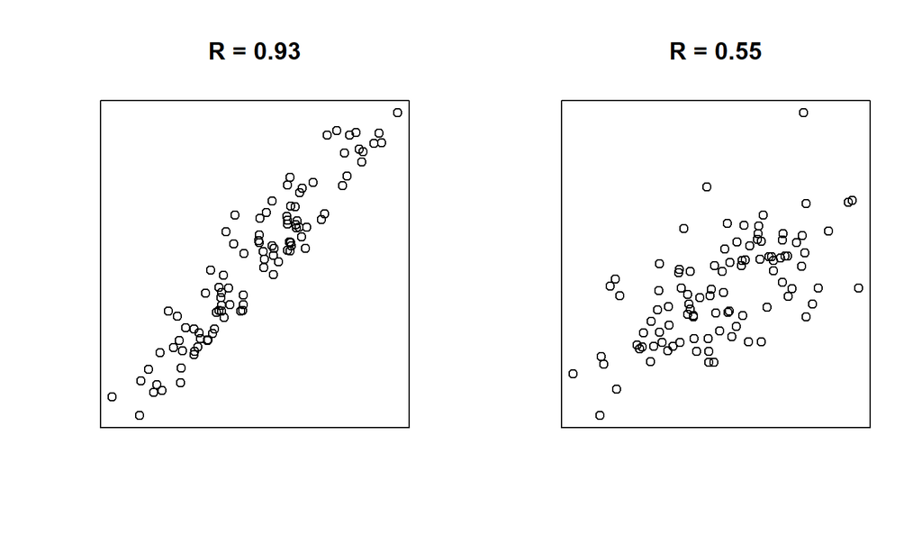

## More Examples

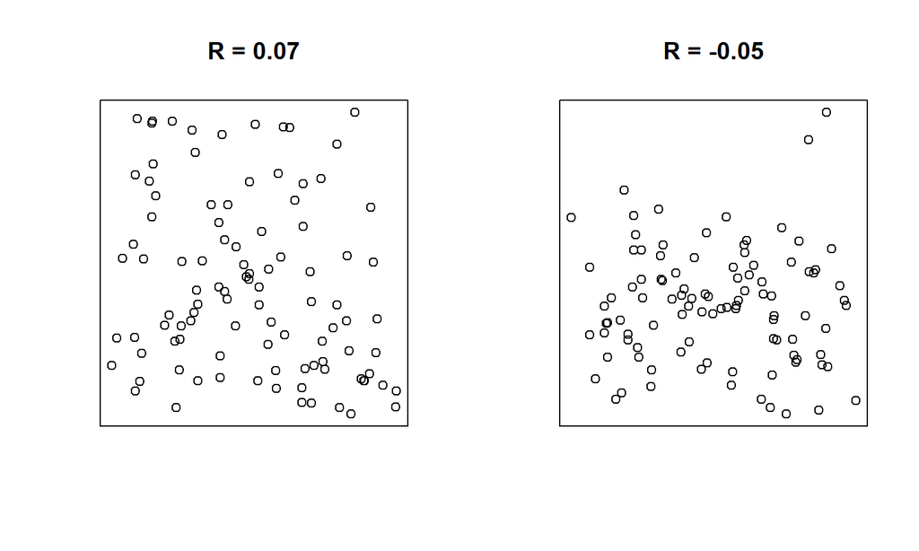

## Even More Examples

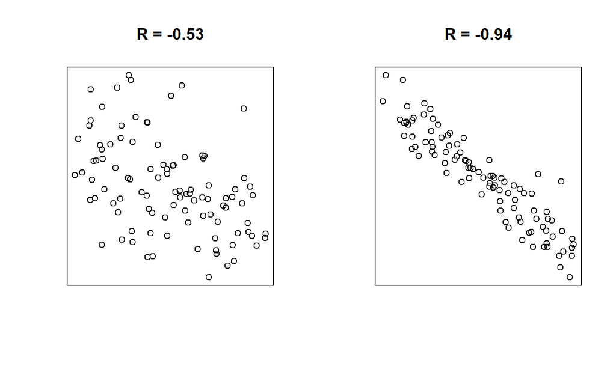

When two variables are highly correlated (\(R\) close to \(-1\) or \(1\))

- we know there is a strong *relationship* between them
- BUT we do not know what *causes* that relationship

That is, **correlation does not imply causation**.

A final note:

- Obviously there’s a strong relationship between \(x\) and \(y\).
  - In fact, \(y = x^2\).
- But the *correlation* between \(x\) and \(y\) is 0!

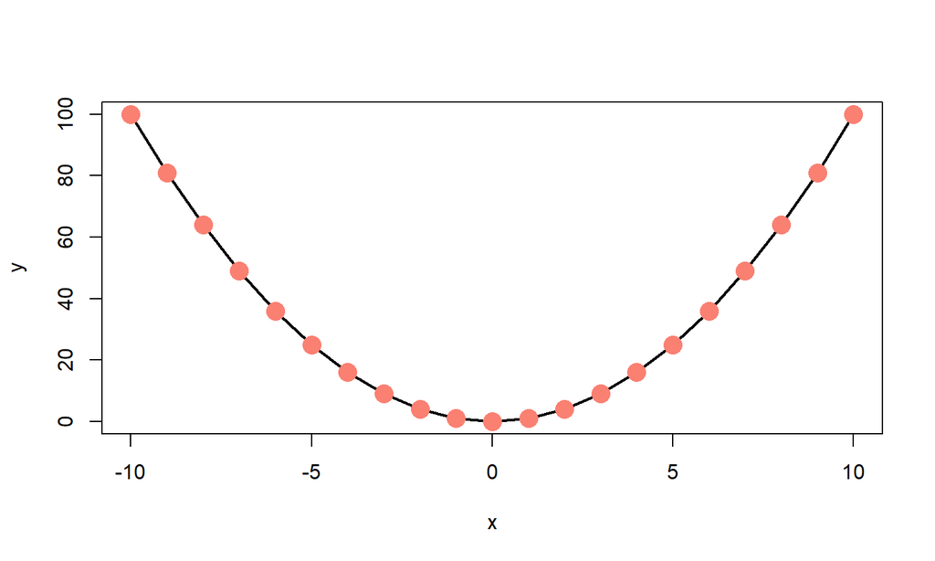